# Table Course Outline

# Lessons

## Lesson 1: Get data into right format

### Video Overview

The first lesson is about getting the data to the right format before we can even begin to build the table. Regardless of what package you use to create the table, it will just take your data frame and put it into a table as it is. Thus, you need to rearrange that data in your data frame before even calling, say, `flextable()`.

The most powerful function to get this job done are `pivot_wider()` and `pivot_longer()`, they are able to transition the data frame from long format to white format and vice versa.

```r
library(tidyverse)
penguins <- palmerpenguins::penguins |>
  filter(!is.na(sex))
penguins
```

```
# A tibble: 333 × 8
   species island    bill_length_mm bill_depth_mm flipper_…¹ body_…² sex    year
   <fct>   <fct>              <dbl>         <dbl>      <int>   <int> <fct> <int>
 1 Adelie  Torgersen           39.1          18.7        181    3750 male   2007
 2 Adelie  Torgersen           39.5          17.4        186    3800 fema…  2007
 3 Adelie  Torgersen           40.3          18          195    3250 fema…  2007
 4 Adelie  Torgersen           36.7          19.3        193    3450 fema…  2007
 5 Adelie  Torgersen           39.3          20.6        190    3650 male   2007
 6 Adelie  Torgersen           38.9          17.8        181    3625 fema…  2007
 7 Adelie  Torgersen           39.2          19.6        195    4675 male   2007
 8 Adelie  Torgersen           41.1          17.6        182    3200 fema…  2007
 9 Adelie  Torgersen           38.6          21.2        191    3800 male   2007
10 Adelie  Torgersen           34.6          21.1        198    4400 male   2007
# … with 323 more rows, and abbreviated variable names ¹flipper_length_mm,
#   ²body_mass_g
```

```r
penguin_counts <- penguins |>
  mutate(year = as.character(year)) |>
  group_by(species, island, sex, year) |>
  summarise(n = n(), .groups = 'drop')
penguin_counts
```

```
# A tibble: 30 × 5
   species island sex    year      n
   <fct>   <fct>  <fct>  <chr> <int>
 1 Adelie  Biscoe female 2007      5
 2 Adelie  Biscoe female 2008      9
 3 Adelie  Biscoe female 2009      8
 4 Adelie  Biscoe male   2007      5
 5 Adelie  Biscoe male   2008      9
 6 Adelie  Biscoe male   2009      8
 7 Adelie  Dream  female 2007      9
 8 Adelie  Dream  female 2008      8
 9 Adelie  Dream  female 2009     10
10 Adelie  Dream  male   2007     10
# … with 20 more rows
```

```r
penguin_counts_wider <- penguin_counts |>
  pivot_wider(
    names_from = c(species, sex),
    values_from = n
  ) |>
  arrange(island, year)
penguin_counts_wider
```

```
# A tibble: 9 × 8
  island    year  Adelie_female Adelie_male Chinstrap_…¹ Chins…² Gento…³ Gento…⁴
  <fct>     <chr>         <int>       <int>        <int>   <int>   <int>   <int>
1 Biscoe    2007              5           5           NA      NA      16      17
2 Biscoe    2008              9           9           NA      NA      22      23
3 Biscoe    2009              8           8           NA      NA      20      21
4 Dream     2007              9          10           13      13      NA      NA
5 Dream     2008              8           8            9       9      NA      NA
6 Dream     2009             10          10           12      12      NA      NA
7 Torgersen 2007              8           7           NA      NA      NA      NA
8 Torgersen 2008              8           8           NA      NA      NA      NA
9 Torgersen 2009              8           8           NA      NA      NA      NA
# … with abbreviated variable names ¹Chinstrap_female, ²Chinstrap_male,
#   ³Gentoo_female, ⁴Gentoo_male
```

```r
# For demo purposes revert with pivot_longer()
penguin_counts_wider |>
  pivot_longer(
    cols = -(1:2),
    names_to = c('species', 'sex'),
    names_sep = '_'
  )
```

```
# A tibble: 54 × 5
   island year  species   sex    value
   <fct>  <chr> <chr>     <chr>  <int>
 1 Biscoe 2007  Adelie    female     5
 2 Biscoe 2007  Adelie    male       5
 3 Biscoe 2007  Chinstrap female    NA
 4 Biscoe 2007  Chinstrap male      NA
 5 Biscoe 2007  Gentoo    female    16
 6 Biscoe 2007  Gentoo    male      17
 7 Biscoe 2008  Adelie    female     9
 8 Biscoe 2008  Adelie    male       9
 9 Biscoe 2008  Chinstrap female    NA
10 Biscoe 2008  Chinstrap male      NA
# … with 44 more rows
```

### Code and Video solutions

### Learn more

## Lesson 2: Avoid vertical lines with `flextable()`

### Video Overview

Call `flextable()` and review that it’s good to avoid vertical lines. Also, call `autofit()` so that column widths are adjust to some optimum.

```r
library(flextable)
library(officer) # Load as well for later theming.

flextable(penguin_counts_wider) |>
  autofit()
```

| island | year | Adelie_female | Adelie_male | Chinstrap_female | Chinstrap_male | Gentoo_female | Gentoo_male |
| --- | --- | --- | --- | --- | --- | --- | --- |
| Biscoe | 2007 | 5 | 5 |  |  | 16 | 17 |
| Biscoe | 2008 | 9 | 9 |  |  | 22 | 23 |
| Biscoe | 2009 | 8 | 8 |  |  | 20 | 21 |
| Dream | 2007 | 9 | 10 | 13 | 13 |  |  |
| Dream | 2008 | 8 | 8 | 9 | 9 |  |  |
| Dream | 2009 | 10 | 10 | 12 | 12 |  |  |
| Torgersen | 2007 | 8 | 7 |  |  |  |  |
| Torgersen | 2008 | 8 | 8 |  |  |  |  |
| Torgersen | 2009 | 8 | 8 |  |  |  |  |

### Code and Video solutions

### Learn more

## Lesson 3: Use better column names and a title

### Video Overview

Next up, we need to use better column names. That’s because `flextable()` prints a data frame as is. Consequently, column names may not really be human readable at all. For example, column names may contain underscores or some other kind of unusual notation.

While we’re at it, we should avoid duplicating a lot of column names. For example, in this example, we see that we always repeat the species name. To avoid that it’s best to add a novel row of so-called spanners. Furthermore, we should add one more important label, i.e. a title.

```r
flextable(penguin_counts_wider) |>
  set_header_labels(
    island = 'Island',
    year = 'Year',
    Adelie_female = 'Female',
    Adelie_male = 'Male',
    Chinstrap_female = 'Female',
    Chinstrap_male = 'Male',
    Gentoo_female = 'Female',
    Gentoo_male = 'Male'
  ) |>
  add_header_row(
    values = c('', 'Adelie', 'Chinstrap', 'Gentoo'),
    colwidths = c(2, 2, 2, 2)
  ) |>
  add_header_lines(
    values = c('Penguins in the Palmer Archipelago', 'Data is courtesy of the {palmerpenguins} R package')
  ) |>
  autofit()
```

| Penguins in the Palmer Archipelago Data is courtesy of the {palmerpenguins} R package Island | Penguins in the Palmer Archipelago Data is courtesy of the {palmerpenguins} R package Year | Penguins in the Palmer Archipelago Data is courtesy of the {palmerpenguins} R package Adelie Female | Penguins in the Palmer Archipelago Data is courtesy of the {palmerpenguins} R package Adelie Male | Penguins in the Palmer Archipelago Data is courtesy of the {palmerpenguins} R package Chinstrap Female | Penguins in the Palmer Archipelago Data is courtesy of the {palmerpenguins} R package Chinstrap Male | Penguins in the Palmer Archipelago Data is courtesy of the {palmerpenguins} R package Gentoo Female | Penguins in the Palmer Archipelago Data is courtesy of the {palmerpenguins} R package Gentoo Male |
| --- | --- | --- | --- | --- | --- | --- | --- |
| Biscoe | 2007 | 5 | 5 |  |  | 16 | 17 |
| Biscoe | 2008 | 9 | 9 |  |  | 22 | 23 |
| Biscoe | 2009 | 8 | 8 |  |  | 20 | 21 |
| Dream | 2007 | 9 | 10 | 13 | 13 |  |  |
| Dream | 2008 | 8 | 8 | 9 | 9 |  |  |
| Dream | 2009 | 10 | 10 | 12 | 12 |  |  |
| Torgersen | 2007 | 8 | 7 |  |  |  |  |
| Torgersen | 2008 | 8 | 8 |  |  |  |  |
| Torgersen | 2009 | 8 | 8 |  |  |  |  |

Alternative

```r
new_names <- c('Island', 'Year', rep(c('Female', 'Male'), 3))
names(new_names) <- colnames(penguin_counts_wider)

flextable(penguin_counts_wider) |>
  set_header_labels(
    values = new_names
  ) |>
  add_header_row(
    values = c('', 'Adelie', 'Chinstrap', 'Gentoo'),
    colwidths = c(2, 2, 2, 2)
  ) |>
  add_header_lines(
    values = c('Penguins in the Palmer Archipelago', 'Data is courtesy of the {palmerpenguins} R package')
  ) |>
  autofit()
```

| Penguins in the Palmer Archipelago Data is courtesy of the {palmerpenguins} R package Island | Penguins in the Palmer Archipelago Data is courtesy of the {palmerpenguins} R package Year | Penguins in the Palmer Archipelago Data is courtesy of the {palmerpenguins} R package Adelie Female | Penguins in the Palmer Archipelago Data is courtesy of the {palmerpenguins} R package Adelie Male | Penguins in the Palmer Archipelago Data is courtesy of the {palmerpenguins} R package Chinstrap Female | Penguins in the Palmer Archipelago Data is courtesy of the {palmerpenguins} R package Chinstrap Male | Penguins in the Palmer Archipelago Data is courtesy of the {palmerpenguins} R package Gentoo Female | Penguins in the Palmer Archipelago Data is courtesy of the {palmerpenguins} R package Gentoo Male |
| --- | --- | --- | --- | --- | --- | --- | --- |
| Biscoe | 2007 | 5 | 5 |  |  | 16 | 17 |
| Biscoe | 2008 | 9 | 9 |  |  | 22 | 23 |
| Biscoe | 2009 | 8 | 8 |  |  | 20 | 21 |
| Dream | 2007 | 9 | 10 | 13 | 13 |  |  |
| Dream | 2008 | 8 | 8 | 9 | 9 |  |  |
| Dream | 2009 | 10 | 10 | 12 | 12 |  |  |
| Torgersen | 2007 | 8 | 7 |  |  |  |  |
| Torgersen | 2008 | 8 | 8 |  |  |  |  |
| Torgersen | 2009 | 8 | 8 |  |  |  |  |

### Code and Video solutions

### Learn more

## Lesson 4: Align columns

### Video Overview

Next step is to align columns. As you as you can see, for example, in our spanners, the cells use right aligned texts. That’s not particularly nice to read, especially because this species name should always refer to the two cells below it. So it would be great if the text in that cell is centered.

For readability of your tables certain data types should use different alignments. For example, for texts it’s best if you use left alignment. That’s because we read from left to right and if all the texts are aligned at the same vertical line, then it’s easier to read. Otherwise, our eyes always have to find the beginning of the next line.

For numbers it’s different. There, you should move everything to the right. This way, you can easily compare digits one by one.

```r
flextable(penguin_counts_wider) |>
  set_header_labels(
    island = 'Island',
    year = 'Year',
    Adelie_female = 'Female',
    Adelie_male = 'Male',
    Chinstrap_female = 'Female',
    Chinstrap_male = 'Male',
    Gentoo_female = 'Female',
    Gentoo_male = 'Male'
  ) |>
  add_header_row(
    values = c('', 'Adelie', 'Chinstrap', 'Gentoo'),
    colwidths = c(2, 2, 2, 2)
  ) |>
  add_header_lines(
    values = c('Penguins in the Palmer Archipelago', 'Data is courtesy of the {palmerpenguins} R package')
  ) |>
  align(i = 3, align = 'center', part = 'header') |>
  # it's already left-aligned but for demo purposes we do it again
  align(j = 'year', align = 'right', part = 'body') |>
  autofit()
```

| Penguins in the Palmer Archipelago Data is courtesy of the {palmerpenguins} R package Island | Penguins in the Palmer Archipelago Data is courtesy of the {palmerpenguins} R package Year | Penguins in the Palmer Archipelago Data is courtesy of the {palmerpenguins} R package Adelie Female | Penguins in the Palmer Archipelago Data is courtesy of the {palmerpenguins} R package Adelie Male | Penguins in the Palmer Archipelago Data is courtesy of the {palmerpenguins} R package Chinstrap Female | Penguins in the Palmer Archipelago Data is courtesy of the {palmerpenguins} R package Chinstrap Male | Penguins in the Palmer Archipelago Data is courtesy of the {palmerpenguins} R package Gentoo Female | Penguins in the Palmer Archipelago Data is courtesy of the {palmerpenguins} R package Gentoo Male |
| --- | --- | --- | --- | --- | --- | --- | --- |
| Biscoe | 2007 | 5 | 5 |  |  | 16 | 17 |
| Biscoe | 2008 | 9 | 9 |  |  | 22 | 23 |
| Biscoe | 2009 | 8 | 8 |  |  | 20 | 21 |
| Dream | 2007 | 9 | 10 | 13 | 13 |  |  |
| Dream | 2008 | 8 | 8 | 9 | 9 |  |  |
| Dream | 2009 | 10 | 10 | 12 | 12 |  |  |
| Torgersen | 2007 | 8 | 7 |  |  |  |  |
| Torgersen | 2008 | 8 | 8 |  |  |  |  |
| Torgersen | 2009 | 8 | 8 |  |  |  |  |

### Code and Video solutions

### Learn more

## Lesson 5: Use groups instead of repetitive columns

### Video Overview

Next, it’s better to use groups instead of repetitive columns. For instance, the island column repeats itself multiple times before we move on to the next island name. This is a doesn’t really look good. And it would be nice if we can just make it visually clearer that certain rows belong to certain islands.

```r
penguin_counts_wider |>
  mutate(island = paste('Island: ', island)) |>
  as_grouped_data(
    groups = 'island'
  ) |>
  as_flextable(hide_grouplabel = TRUE) |>
  set_header_labels(
    island = 'Island',
    year = '',
    Adelie_female = 'Female',
    Adelie_male = 'Male',
    Chinstrap_female = 'Female',
    Chinstrap_male = 'Male',
    Gentoo_female = 'Female',
    Gentoo_male = 'Male'
  ) |>
  add_header_row(
    values = c('', 'Adelie', 'Chinstrap', 'Gentoo'),
    colwidths = c(1, 2, 2, 2)
  ) |>
  add_header_lines(
    values = c('Penguins in the Palmer Archipelago', 'Data is courtesy of the {palmerpenguins} R package')
  ) |>
  align(i = 3, align = 'center', part = 'header') |>
  autofit()
```

| Penguins in the Palmer Archipelago Data is courtesy of the {palmerpenguins} R package | Penguins in the Palmer Archipelago Data is courtesy of the {palmerpenguins} R package Adelie Female | Penguins in the Palmer Archipelago Data is courtesy of the {palmerpenguins} R package Adelie Male | Penguins in the Palmer Archipelago Data is courtesy of the {palmerpenguins} R package Chinstrap Female | Penguins in the Palmer Archipelago Data is courtesy of the {palmerpenguins} R package Chinstrap Male | Penguins in the Palmer Archipelago Data is courtesy of the {palmerpenguins} R package Gentoo Female | Penguins in the Palmer Archipelago Data is courtesy of the {palmerpenguins} R package Gentoo Male |
| --- | --- | --- | --- | --- | --- | --- |
| Island: Biscoe |  |  |  |  |  |  |
| 2007 | 5 | 5 |  |  | 16 | 17 |
| 2008 | 9 | 9 |  |  | 22 | 23 |
| 2009 | 8 | 8 |  |  | 20 | 21 |
| Island: Dream |  |  |  |  |  |  |
| 2007 | 9 | 10 | 13 | 13 |  |  |
| 2008 | 8 | 8 | 9 | 9 |  |  |
| 2009 | 10 | 10 | 12 | 12 |  |  |
| Island: Torgersen |  |  |  |  |  |  |
| 2007 | 8 | 7 |  |  |  |  |
| 2008 | 8 | 8 |  |  |  |  |
| 2009 | 8 | 8 |  |  |  |  |

### Code and Video solutions

### Learn more

## Lesson 6: Format missing numbers

### Video Overview

Notice that our table contains a lot of missing numbers. That’s fine but leaving a lot of white space may be off putting to the reader. So, let’s add small dashes to the empty cells.

This demonstrates how to format missing numbers, but it also explains how format any kind of data. Also, this will introduce formulas for selecting specific cells in the table.

```r
penguin_counts_wider |>
  mutate(island = paste('Island: ', island)) |>
  as_grouped_data(
    groups = 'island'
  ) |>
  as_flextable(hide_grouplabel = TRUE) |>
  set_header_labels(
    island = 'Island',
    year = '',
    Adelie_female = 'Female',
    Adelie_male = 'Male',
    Chinstrap_female = 'Female',
    Chinstrap_male = 'Male',
    Gentoo_female = 'Female',
    Gentoo_male = 'Male'
  ) |>
  add_header_row(
    values = c('', 'Adelie', 'Chinstrap', 'Gentoo'),
    colwidths = c(1, 2, 2, 2)
  ) |>
  add_header_lines(
    values = 'Penguins in the Palmer Archipelago\nData is courtesy of the {palmerpenguins} R package'
  ) |>
  align(i = 2, align = 'center', part = 'header') |>
  colformat_num(i = ~ (is.na(island)), na_str = '-') |>
  autofit()
```

| Penguins in the Palmer Archipelago Data is courtesy of the {palmerpenguins} R package | Penguins in the Palmer Archipelago Data is courtesy of the {palmerpenguins} R package Adelie Female | Penguins in the Palmer Archipelago Data is courtesy of the {palmerpenguins} R package Adelie Male | Penguins in the Palmer Archipelago Data is courtesy of the {palmerpenguins} R package Chinstrap Female | Penguins in the Palmer Archipelago Data is courtesy of the {palmerpenguins} R package Chinstrap Male | Penguins in the Palmer Archipelago Data is courtesy of the {palmerpenguins} R package Gentoo Female | Penguins in the Palmer Archipelago Data is courtesy of the {palmerpenguins} R package Gentoo Male |
| --- | --- | --- | --- | --- | --- | --- |
| Island: Biscoe |  |  |  |  |  |  |
| 2007 | 5 | 5 | - | - | 16 | 17 |
| 2008 | 9 | 9 | - | - | 22 | 23 |
| 2009 | 8 | 8 | - | - | 20 | 21 |
| Island: Dream |  |  |  |  |  |  |
| 2007 | 9 | 10 | 13 | 13 | - | - |
| 2008 | 8 | 8 | 9 | 9 | - | - |
| 2009 | 10 | 10 | 12 | 12 | - | - |
| Island: Torgersen |  |  |  |  |  |  |
| 2007 | 8 | 7 | - | - | - | - |
| 2008 | 8 | 8 | - | - | - | - |
| 2009 | 8 | 8 | - | - | - | - |

### Code and Video solutions

### Learn more

## Lesson 7: Add summaries

### Video Overview

It’s always good to not just show the data, but to also to show a summary of the data. In this case, it could be something as simple as the maximum number of penguins of a specific species living on an island over the years.

```r
maximum_summary <- penguin_counts_wider |>
  group_by(island) |>
  summarise(across(
    .cols = -year,
    .fns = max
  )) |>
  mutate(year = 'Maximum')

total_summary <- penguin_counts_wider |>
  group_by(island) |>
  summarise(across(
    .cols = -year,
    .fns = sum
  )) |>
  mutate(year = 'Total')


bind_rows(penguin_counts_wider, maximum_summary, total_summary) |>
  mutate(island = paste('Island: ', island)) |>
  arrange(island, year) |>
  as_grouped_data(groups = 'island') |>
  as_flextable(hide_grouplabel = TRUE) |>
  set_header_labels(
    island = 'Island',
    year = '',
    Adelie_female = 'Female',
    Adelie_male = 'Male',
    Chinstrap_female = 'Female',
    Chinstrap_male = 'Male',
    Gentoo_female = 'Female',
    Gentoo_male = 'Male'
  ) |>
  add_header_row(
    values = c('', 'Adelie', 'Chinstrap', 'Gentoo'),
    colwidths = c(1, 2, 2, 2)
  ) |>
  add_header_lines(
    values = c('Penguins in the Palmer Archipelago', 'Data is courtesy of the {palmerpenguins} R package')
  ) |>
  align(i = 3, align = 'center', part = 'header') |>
  colformat_num(i = ~ (is.na(island)), na_str = '-') |>
  align(
    i = ~ (year %in% 2007:2009),
    j = 'year',
    align = 'right'
  ) |>
  autofit()
```

| Penguins in the Palmer Archipelago Data is courtesy of the {palmerpenguins} R package | Penguins in the Palmer Archipelago Data is courtesy of the {palmerpenguins} R package Adelie Female | Penguins in the Palmer Archipelago Data is courtesy of the {palmerpenguins} R package Adelie Male | Penguins in the Palmer Archipelago Data is courtesy of the {palmerpenguins} R package Chinstrap Female | Penguins in the Palmer Archipelago Data is courtesy of the {palmerpenguins} R package Chinstrap Male | Penguins in the Palmer Archipelago Data is courtesy of the {palmerpenguins} R package Gentoo Female | Penguins in the Palmer Archipelago Data is courtesy of the {palmerpenguins} R package Gentoo Male |
| --- | --- | --- | --- | --- | --- | --- |
| Island: Biscoe |  |  |  |  |  |  |
| 2007 | 5 | 5 | - | - | 16 | 17 |
| 2008 | 9 | 9 | - | - | 22 | 23 |
| 2009 | 8 | 8 | - | - | 20 | 21 |
| Maximum | 9 | 9 | - | - | 22 | 23 |
| Total | 22 | 22 | - | - | 58 | 61 |
| Island: Dream |  |  |  |  |  |  |
| 2007 | 9 | 10 | 13 | 13 | - | - |
| 2008 | 8 | 8 | 9 | 9 | - | - |
| 2009 | 10 | 10 | 12 | 12 | - | - |
| Maximum | 10 | 10 | 13 | 13 | - | - |
| Total | 27 | 28 | 34 | 34 | - | - |
| Island: Torgersen |  |  |  |  |  |  |
| 2007 | 8 | 7 | - | - | - | - |
| 2008 | 8 | 8 | - | - | - | - |
| 2009 | 8 | 8 | - | - | - | - |
| Maximum | 8 | 8 | - | - | - | - |
| Total | 24 | 23 | - | - | - | - |

### Code and Video solutions

### Learn more

## Lesson 8: Add additional horizontal lines

### Video Overview

We’ve arrived at the probably the most fun lesson in this part of the course which is about theming and making the table more pretty. We’ll start by adding more lines to distinguish our summaries from the rest.

```r
bind_rows(penguin_counts_wider, maximum_summary, total_summary) |>
  mutate(island = paste('Island: ', island)) |>
  arrange(island, year) |>
  as_grouped_data(groups = 'island') |>
  as_flextable(hide_grouplabel = TRUE) |>
  set_header_labels(
    island = 'Island',
    year = '',
    Adelie_female = 'Female',
    Adelie_male = 'Male',
    Chinstrap_female = 'Female',
    Chinstrap_male = 'Male',
    Gentoo_female = 'Female',
    Gentoo_male = 'Male'
  ) |>
  add_header_row(
    values = c('', 'Adelie', 'Chinstrap', 'Gentoo'),
    colwidths = c(1, 2, 2, 2)
  ) |>
  add_header_lines(
    values = c('Penguins in the Palmer Archipelago', 'Data is courtesy of the {palmerpenguins} R package')
  ) |>
  align(i = 3, align = 'center', part = 'header') |>
  colformat_num(i = ~ (is.na(island)), na_str = '-') |>
  align(
    i = ~ (year %in% 2007:2009),
    j = 'year',
    align = 'right'
  ) |>
  hline(i = ~ (!is.na(island) | year %in% c('2009', 'Total'))) |>
  autofit()
```

| Penguins in the Palmer Archipelago Data is courtesy of the {palmerpenguins} R package | Penguins in the Palmer Archipelago Data is courtesy of the {palmerpenguins} R package Adelie Female | Penguins in the Palmer Archipelago Data is courtesy of the {palmerpenguins} R package Adelie Male | Penguins in the Palmer Archipelago Data is courtesy of the {palmerpenguins} R package Chinstrap Female | Penguins in the Palmer Archipelago Data is courtesy of the {palmerpenguins} R package Chinstrap Male | Penguins in the Palmer Archipelago Data is courtesy of the {palmerpenguins} R package Gentoo Female | Penguins in the Palmer Archipelago Data is courtesy of the {palmerpenguins} R package Gentoo Male |
| --- | --- | --- | --- | --- | --- | --- |
| Island: Biscoe |  |  |  |  |  |  |
| 2007 | 5 | 5 | - | - | 16 | 17 |
| 2008 | 9 | 9 | - | - | 22 | 23 |
| 2009 | 8 | 8 | - | - | 20 | 21 |
| Maximum | 9 | 9 | - | - | 22 | 23 |
| Total | 22 | 22 | - | - | 58 | 61 |
| Island: Dream |  |  |  |  |  |  |
| 2007 | 9 | 10 | 13 | 13 | - | - |
| 2008 | 8 | 8 | 9 | 9 | - | - |
| 2009 | 10 | 10 | 12 | 12 | - | - |
| Maximum | 10 | 10 | 13 | 13 | - | - |
| Total | 27 | 28 | 34 | 34 | - | - |
| Island: Torgersen |  |  |  |  |  |  |
| 2007 | 8 | 7 | - | - | - | - |
| 2008 | 8 | 8 | - | - | - | - |
| 2009 | 8 | 8 | - | - | - | - |
| Maximum | 8 | 8 | - | - | - | - |
| Total | 24 | 23 | - | - | - | - |

### Code and Video solutions

### Learn more

## Lesson 9: Add background colors

### Video Overview

Next, we want to bring a little bit color into our table. Right now it’s all black and white and this looks really dull.

```r
bind_rows(penguin_counts_wider, maximum_summary, total_summary) |>
  mutate(island = paste('Island: ', island)) |>
  arrange(island, year) |>
  as_grouped_data(groups = 'island') |>
  as_flextable(hide_grouplabel = TRUE) |>
  set_header_labels(
    island = 'Island',
    year = '',
    Adelie_female = 'Female',
    Adelie_male = 'Male',
    Chinstrap_female = 'Female',
    Chinstrap_male = 'Male',
    Gentoo_female = 'Female',
    Gentoo_male = 'Male'
  ) |>
  add_header_row(
    values = c('', 'Adelie', 'Chinstrap', 'Gentoo'),
    colwidths = c(1, 2, 2, 2)
  ) |>
  add_header_lines(
    values = c('Penguins in the Palmer Archipelago', 'Data is courtesy of the {palmerpenguins} R package')
  ) |>
  align(i = 3, align = 'center', part = 'header') |>
  colformat_num(i = ~ (is.na(island)), na_str = '-') |>
  align(
    i = ~ (year %in% 2007:2009),
    j = 'year',
    align = 'right'
  ) |>
  hline(i = ~ (!is.na(island) | year %in% c('2009', 'Total'))) |>
  bg(i = 3:4, bg = 'dodgerblue4', part = 'header') |>
  bg(i = ~ (year %in% seq(2007, 2009, 2)), bg = 'grey90') |>
  autofit()
```

| Penguins in the Palmer Archipelago Data is courtesy of the {palmerpenguins} R package | Penguins in the Palmer Archipelago Data is courtesy of the {palmerpenguins} R package Adelie Female | Penguins in the Palmer Archipelago Data is courtesy of the {palmerpenguins} R package Adelie Male | Penguins in the Palmer Archipelago Data is courtesy of the {palmerpenguins} R package Chinstrap Female | Penguins in the Palmer Archipelago Data is courtesy of the {palmerpenguins} R package Chinstrap Male | Penguins in the Palmer Archipelago Data is courtesy of the {palmerpenguins} R package Gentoo Female | Penguins in the Palmer Archipelago Data is courtesy of the {palmerpenguins} R package Gentoo Male |
| --- | --- | --- | --- | --- | --- | --- |
| Island: Biscoe |  |  |  |  |  |  |
| 2007 | 5 | 5 | - | - | 16 | 17 |
| 2008 | 9 | 9 | - | - | 22 | 23 |
| 2009 | 8 | 8 | - | - | 20 | 21 |
| Maximum | 9 | 9 | - | - | 22 | 23 |
| Total | 22 | 22 | - | - | 58 | 61 |
| Island: Dream |  |  |  |  |  |  |
| 2007 | 9 | 10 | 13 | 13 | - | - |
| 2008 | 8 | 8 | 9 | 9 | - | - |
| 2009 | 10 | 10 | 12 | 12 | - | - |
| Maximum | 10 | 10 | 13 | 13 | - | - |
| Total | 27 | 28 | 34 | 34 | - | - |
| Island: Torgersen |  |  |  |  |  |  |
| 2007 | 8 | 7 | - | - | - | - |
| 2008 | 8 | 8 | - | - | - | - |
| 2009 | 8 | 8 | - | - | - | - |
| Maximum | 8 | 8 | - | - | - | - |
| Total | 24 | 23 | - | - | - | - |

### Code and Video solutions

### Learn more

## Lesson 10: Change text appearance

### Video Overview

This will introduce `bold()`, `color()`, `style()` and `fp_text()` (from `{officer}`)

```r
bind_rows(penguin_counts_wider, maximum_summary, total_summary) |>
  arrange(island, year) |>
  mutate(island = paste('Island: ', island)) |>
  as_grouped_data(groups = 'island') |>
  as_flextable(hide_grouplabel = TRUE) |>
  set_header_labels(
    island = 'Island',
    year = '',
    Adelie_female = 'Female',
    Adelie_male = 'Male',
    Chinstrap_female = 'Female',
    Chinstrap_male = 'Male',
    Gentoo_female = 'Female',
    Gentoo_male = 'Male'
  ) |>
  add_header_row(
    values = c('', 'Adelie', 'Chinstrap', 'Gentoo'),
    colwidths = c(1, 2, 2, 2)
  ) |>
  add_header_lines(
    values = c('Penguins in the Palmer Archipelago', 'Data is courtesy of the {palmerpenguins} R package')
  ) |>
  align(i = 3, align = 'center', part = 'header') |>
  colformat_num(i = ~ (is.na(island)), na_str = '-') |>
  align(
    i = ~ (year %in% 2007:2009),
    j = 'year',
    align = 'right'
  ) |>
  hline(i = ~ (!is.na(island) | year %in% c('2009', 'Total'))) |>
  bg(i = 3:4, bg = 'dodgerblue4', part = 'header') |>
  bg(i = ~ (year %in% seq(2007, 2009, 2)), bg = 'grey90') |>
  bold(part = 'header', i = 3) |>
  color(i = 3:4, part = 'header', color = 'white') |>
  style( #### subtitle
    part = 'header',
    i = 2,
    pr_t = fp_text(font.size = 10),
  ) |>
  style( ### title
    part = 'header',
    i = 1,
    pr_t = fp_text(
      color = 'dodgerblue4',
      font.size = 18,
      font.family = 'Merriweather',
      bold = TRUE
    )
  ) |>
  style( ### group rows
    i = ~ (!is.na(island)),
    pr_t = fp_text(
      color = 'dodgerblue4',
      bold = TRUE,
      font.size = 12,
    )
  ) |>
  autofit()
```

| Penguins in the Palmer Archipelago Data is courtesy of the {palmerpenguins} R package | Penguins in the Palmer Archipelago Data is courtesy of the {palmerpenguins} R package Adelie Female | Penguins in the Palmer Archipelago Data is courtesy of the {palmerpenguins} R package Adelie Male | Penguins in the Palmer Archipelago Data is courtesy of the {palmerpenguins} R package Chinstrap Female | Penguins in the Palmer Archipelago Data is courtesy of the {palmerpenguins} R package Chinstrap Male | Penguins in the Palmer Archipelago Data is courtesy of the {palmerpenguins} R package Gentoo Female | Penguins in the Palmer Archipelago Data is courtesy of the {palmerpenguins} R package Gentoo Male |
| --- | --- | --- | --- | --- | --- | --- |
| Island: Biscoe |  |  |  |  |  |  |
| 2007 | 5 | 5 | - | - | 16 | 17 |
| 2008 | 9 | 9 | - | - | 22 | 23 |
| 2009 | 8 | 8 | - | - | 20 | 21 |
| Maximum | 9 | 9 | - | - | 22 | 23 |
| Total | 22 | 22 | - | - | 58 | 61 |
| Island: Dream |  |  |  |  |  |  |
| 2007 | 9 | 10 | 13 | 13 | - | - |
| 2008 | 8 | 8 | 9 | 9 | - | - |
| 2009 | 10 | 10 | 12 | 12 | - | - |
| Maximum | 10 | 10 | 13 | 13 | - | - |
| Total | 27 | 28 | 34 | 34 | - | - |
| Island: Torgersen |  |  |  |  |  |  |
| 2007 | 8 | 7 | - | - | - | - |
| 2008 | 8 | 8 | - | - | - | - |
| 2009 | 8 | 8 | - | - | - | - |
| Maximum | 8 | 8 | - | - | - | - |
| Total | 24 | 23 | - | - | - | - |

### Code and Video solutions

### Learn more

## Lesson 11: Change cell properties

### Video Overview

This will introduce `border()`, `line_spacing()`, `fp_cell()` and `fp_border()`.

```r
final_table <- bind_rows(penguin_counts_wider, maximum_summary, total_summary) |>
  arrange(island, year) |>
  mutate(island = paste('Island: ', island)) |>
  as_grouped_data(groups = 'island') |>
  as_flextable(hide_grouplabel = TRUE) |>
  set_header_labels(
    island = 'Island',
    year = '',
    Adelie_female = 'Female',
    Adelie_male = 'Male',
    Chinstrap_female = 'Female',
    Chinstrap_male = 'Male',
    Gentoo_female = 'Female',
    Gentoo_male = 'Male'
  ) |>
  add_header_row(
    values = c('', 'Adelie', 'Chinstrap', 'Gentoo'),
    colwidths = c(1, 2, 2, 2)
  ) |>
  add_header_lines(
    values = c('Penguins in the Palmer Archipelago', 'Data is courtesy of the {palmerpenguins} R package')
  ) |>
  align(i = 3, align = 'center', part = 'header') |>
  colformat_num(i = ~ (is.na(island)), na_str = '-') |>
  align(
    i = ~ (year %in% 2007:2009),
    j = 'year',
    align = 'right'
  ) |>
  hline(i = ~ (!is.na(island) | year %in% c('2009', 'Total')), border = fp_border(width = 1, color = 'grey40')) |>
  bg(i = 3:4, bg = 'dodgerblue4', part = 'header') |>
  bg(i = ~ (year %in% seq(2007, 2009, 2)), bg = 'grey90') |>
  bold(part = 'header', i = 3) |>
  color(i = 3:4, part = 'header', color = 'white') |>
  border(j = 'year', border.right = fp_border(color = 'grey40', width = 1)) |>
  style( #### subtitle
    part = 'header',
    i = 2,
    pr_t = fp_text(font.size = 11),
    ### This part is added
    pr_c = fp_cell(border = fp_border(width = 0, color = 'grey40'))
  ) |>
  style( ### title
    part = 'header',
    i = 1,
    pr_t = fp_text(
      color = 'dodgerblue4',
      font.size = 18,
      font.family = 'Merriweather',
      bold = TRUE
    ),
    ### This part is added
    pr_c = fp_cell(
      border.top = fp_border(width = 1.5, color = 'grey40'),
      border.bottom = fp_border(width = 0, color = 'grey40')
    )
  ) |>
  style( ### group rows
    i = ~ (!is.na(island)),
    ### This part is added
    pr_c = fp_cell(
      border.top = fp_border(width = 1, color = 'grey40'),
      border.bottom = fp_border(width = 1, color = 'grey40'),
      border.right = fp_border(width = 0, color = 'grey40')
    ),
    pr_t = fp_text(
      color = 'dodgerblue4',
      bold = TRUE,
      font.size = 12,
    )
  ) |>
  line_spacing(part= 'all', space = 0.9) |>
  ### This part is added
  hline(part = 'header', i = 2, border = fp_border(width = 0)) |>
  hline(part = 'header', i = 3, border = fp_border(width = 0)) |>
  autofit()
final_table
```

| Penguins in the Palmer Archipelago Data is courtesy of the {palmerpenguins} R package | Penguins in the Palmer Archipelago Data is courtesy of the {palmerpenguins} R package Adelie Female | Penguins in the Palmer Archipelago Data is courtesy of the {palmerpenguins} R package Adelie Male | Penguins in the Palmer Archipelago Data is courtesy of the {palmerpenguins} R package Chinstrap Female | Penguins in the Palmer Archipelago Data is courtesy of the {palmerpenguins} R package Chinstrap Male | Penguins in the Palmer Archipelago Data is courtesy of the {palmerpenguins} R package Gentoo Female | Penguins in the Palmer Archipelago Data is courtesy of the {palmerpenguins} R package Gentoo Male |
| --- | --- | --- | --- | --- | --- | --- |
| Island: Biscoe |  |  |  |  |  |  |
| 2007 | 5 | 5 | - | - | 16 | 17 |
| 2008 | 9 | 9 | - | - | 22 | 23 |
| 2009 | 8 | 8 | - | - | 20 | 21 |
| Maximum | 9 | 9 | - | - | 22 | 23 |
| Total | 22 | 22 | - | - | 58 | 61 |
| Island: Dream |  |  |  |  |  |  |
| 2007 | 9 | 10 | 13 | 13 | - | - |
| 2008 | 8 | 8 | 9 | 9 | - | - |
| 2009 | 10 | 10 | 12 | 12 | - | - |
| Maximum | 10 | 10 | 13 | 13 | - | - |
| Total | 27 | 28 | 34 | 34 | - | - |
| Island: Torgersen |  |  |  |  |  |  |
| 2007 | 8 | 7 | - | - | - | - |
| 2008 | 8 | 8 | - | - | - | - |
| 2009 | 8 | 8 | - | - | - | - |
| Maximum | 8 | 8 | - | - | - | - |
| Total | 24 | 23 | - | - | - | - |

### Code and Video solutions

### Learn more

## Lesson 12: Export

### Video Overview

Pretty straightforward what will happen here

```r
save_as_docx(
  final_table,
  path = 'final_table.docx'
)

# Make sure that you have {webshot2} and phantomJS installed. The latter can be installed via {webshot2}
save_as_image(
  final_table,
  path = 'final_table.png',
  webshot = 'webshot2'
)
```

```
[1] "/media/albert/Files/NextCloud/R Projects/tables-course/final_table.png"
```

```r
# Beware that in the output pptx file there can be empty cells that have huge font.
# This will cause the line heights of the cells to be large.
# You have to manually tweak this.
save_as_pptx(
  final_table,
  path = 'table.pptx'
)
```

### Code and Video solutions

### Learn more

## Lesson 13: Heatmap columns

### Video Overview

This lesson covers heat maps. These are tables where one, multiple or all cells have a background color which is chosen according to some numeric value Heat maps are great for helping your reader find the important values or the high or low values immediately.

```r
bg_color_fct <- scales::col_numeric(palette = "viridis", domain = c(0, 30), na.color = 'white')
text_color_fct <- function(x) if_else(x < 20 & !is.na(x), 'white', 'black')

## Source needs to take the grouped data into account. That's why it's shifted by one.
final_table |>
  bg(i = ~(year %in% 2007:2009), j = 2:7, bg = bg_color_fct, source = 3:8) |>
  color(i = ~(year %in% 2007:2009), j = 2:7, color = text_color_fct,source = 3:8)
```

| Penguins in the Palmer Archipelago Data is courtesy of the {palmerpenguins} R package | Penguins in the Palmer Archipelago Data is courtesy of the {palmerpenguins} R package Adelie Female | Penguins in the Palmer Archipelago Data is courtesy of the {palmerpenguins} R package Adelie Male | Penguins in the Palmer Archipelago Data is courtesy of the {palmerpenguins} R package Chinstrap Female | Penguins in the Palmer Archipelago Data is courtesy of the {palmerpenguins} R package Chinstrap Male | Penguins in the Palmer Archipelago Data is courtesy of the {palmerpenguins} R package Gentoo Female | Penguins in the Palmer Archipelago Data is courtesy of the {palmerpenguins} R package Gentoo Male |
| --- | --- | --- | --- | --- | --- | --- |
| Island: Biscoe |  |  |  |  |  |  |
| 2007 | 5 | 5 | - | - | 16 | 17 |
| 2008 | 9 | 9 | - | - | 22 | 23 |
| 2009 | 8 | 8 | - | - | 20 | 21 |
| Maximum | 9 | 9 | - | - | 22 | 23 |
| Total | 22 | 22 | - | - | 58 | 61 |
| Island: Dream |  |  |  |  |  |  |
| 2007 | 9 | 10 | 13 | 13 | - | - |
| 2008 | 8 | 8 | 9 | 9 | - | - |
| 2009 | 10 | 10 | 12 | 12 | - | - |
| Maximum | 10 | 10 | 13 | 13 | - | - |
| Total | 27 | 28 | 34 | 34 | - | - |
| Island: Torgersen |  |  |  |  |  |  |
| 2007 | 8 | 7 | - | - | - | - |
| 2008 | 8 | 8 | - | - | - | - |
| 2009 | 8 | 8 | - | - | - | - |
| Maximum | 8 | 8 | - | - | - | - |
| Total | 24 | 23 | - | - | - | - |

### Code and Video solutions

### Learn more

## Lesson 14: Sparklines

### Video Overview

Sparklines are small lines that help you to find trends in the data really fast. By now, they’re one of the standard tricks in the table trade.

species

island

sex

collected_data

Adelie

Biscoe

female

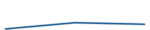

Adelie

Biscoe

male

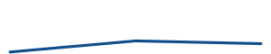

Adelie

Dream

female

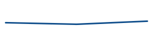

Adelie

Dream

male

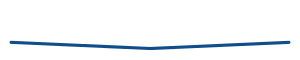

Adelie

Torgersen

female

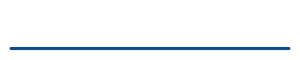

Adelie

Torgersen

male

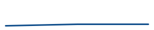

Chinstrap

Dream

female

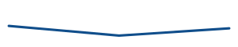

Chinstrap

Dream

male

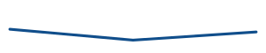

Gentoo

Biscoe

female

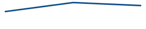

Gentoo

Biscoe

male

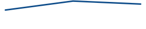

```r
counts_over_time <- penguin_counts |>
  group_by(species, island, sex) |>
  summarise(collected_data = list(n)) |>
  ungroup()


counts_over_time |>
  flextable() |>
  compose(j = 'collected_data', value = as_paragraph(
    plot_chunk(value = collected_data, type = 'line', col = 'dodgerblue4')
  ))
```

species

body_masses

Adelie

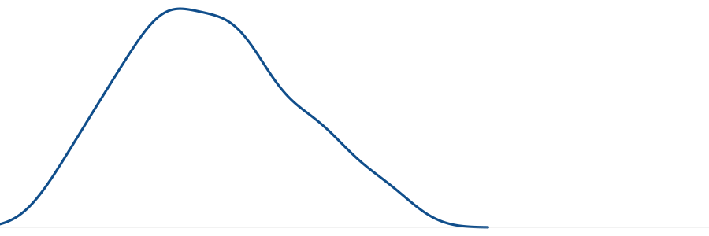

Chinstrap

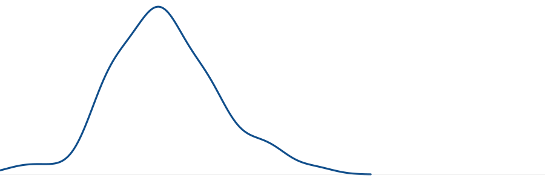

Gentoo

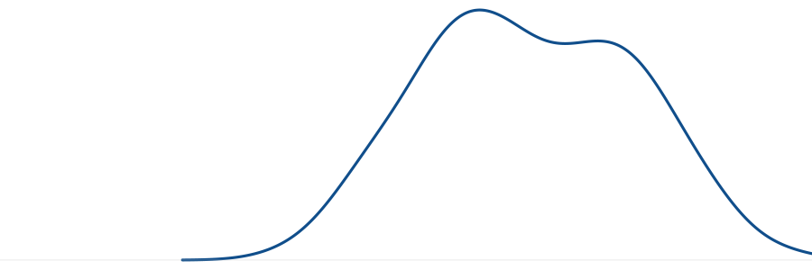

```r
penguin_mass <- penguins |>
  group_by(species) |>
  summarise(body_masses = list(body_mass_g)) |>
  ungroup()

penguin_mass |>
  flextable() |>
  compose(
    j = 'body_masses',
    value = as_paragraph(
      plot_chunk(
        value = body_masses,
        type = 'dens',
        col = 'dodgerblue4',
        width = 3,
        height = 1
      )
    )
  )
```

### Code and Video solutions

### Learn more

## Lesson 15: Add your own ggplot

### Video Overview

Let’s redo our own density plots.

species

body_masses

Adelie

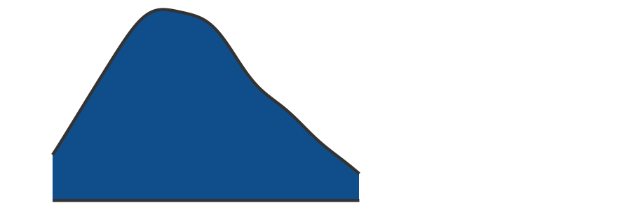

Chinstrap

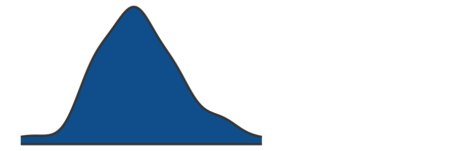

Gentoo

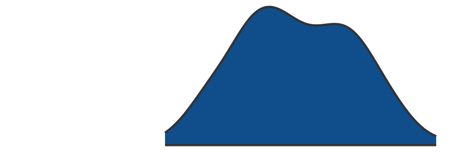

```r
single_species_weights <- penguin_mass$body_masses[[1]]

gg_density_plot <- function(weights) {
  ggplot() +
    stat_density(aes(x = weights), fill = 'dodgerblue4', col = 'grey20') +
    coord_cartesian(xlim = range(penguins$body_mass_g)) +
    theme_void()
}


list_of_ggplots <- map(penguin_mass$body_masses, gg_density_plot)


penguin_mass |>
  flextable() |>
  compose(
    j = 'body_masses',
    value = as_paragraph(
      gg_chunk(
        value = list_of_ggplots,
        width = 3,
        height = 1
      )
    )
  )
```

species

body_masses

Adelie

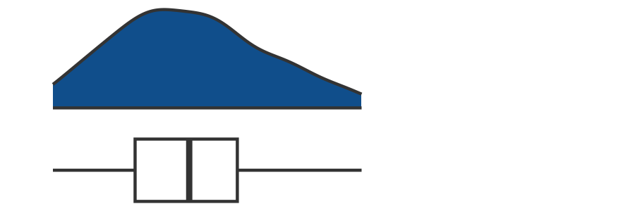

Chinstrap

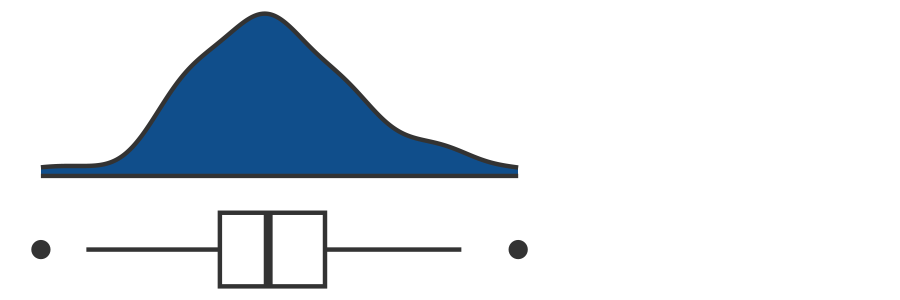

Gentoo

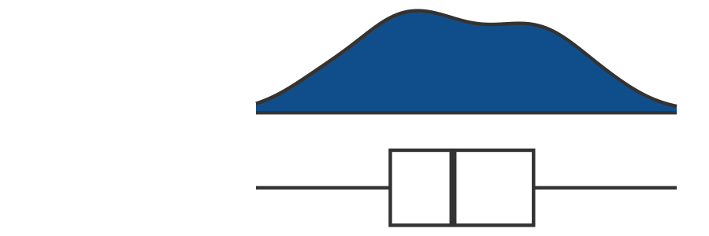

```r
gg_density_box_plot <- function(weights) {
  ggplot(mapping = aes(x = weights)) +
    stat_density(fill = 'dodgerblue4', col = 'grey20') +
    geom_boxplot(width = 0.0005, position = position_nudge(y = -0.0005)) +
    coord_cartesian(xlim = range(penguins$body_mass_g)) +
    theme_void()
}

list_of_ggplots <- map(penguin_mass$body_masses, gg_density_box_plot)


penguin_mass |>
  flextable() |>
  compose(
    j = 'body_masses',
    value = as_paragraph(
      gg_chunk(
        value = list_of_ggplots,
        width = 3,
        height = 1
      )
    )
  )
```

### Code and Video solutions

### Learn more

Images and some more mini charts at https://ardata-fr.github.io/flextable-book/cell-content-1.html#images

## Lesson 16: Case study (Either a long video or split into parts)

### Video Overview

Take a NYT table or something from FiveThirtyEight

```r
library(officer)
library(flextable)

library(tidyverse)
library(lubridate)

big_tech_stock_prices <- readr::read_csv('https://raw.githubusercontent.com/rfordatascience/tidytuesday/master/data/2023/2023-02-07/big_tech_stock_prices.csv')
big_tech_companies <- readr::read_csv('https://raw.githubusercontent.com/rfordatascience/tidytuesday/master/data/2023/2023-02-07/big_tech_companies.csv')

stocks <- big_tech_stock_prices |>
  left_join(big_tech_companies) |>
  arrange(company, date)

covid_period <- stocks |>
  filter(date %in% c(make_date(2020, 1, 2), make_date(2022, 12, 29)))

covid_changes <- covid_period |>
  group_by(stock_symbol, company) |>
  nest() |>
  mutate(
    change_abs = map_dbl(data, \(x) (x$open[2] - x$open[1])),
    change_rel = map_dbl(data, \(x) (x$open[2]/x$open[1] - 1)),
    percent = scales::percent(change_rel, accuracy = 0.01)
  ) |>
  ungroup() |>
  arrange(change_rel) |>
  select(-data)


open_prices <- covid_period |>
  select(stock_symbol, open, date) |>
  mutate(date = as.character(year(date))) |>
  pivot_wider(
    id_cols = stock_symbol,
    names_from = date,
    names_prefix = 'open',
    values_from = 'open'
  )


chart_line_color <- 'grey20'
chart_segment_color_pos <- 'seagreen'
chart_segment_color_neg <-  'firebrick4'

tbl_data <- covid_changes |>
  left_join(open_prices) |>
  select(company, open2020, open2022, change_abs, percent, stock_symbol)  |>
  mutate(
    company = if_else(stock_symbol == 'IBM', 'IBM', company),
    company = str_remove(company, '(,)? Inc\\.'),
    company = str_remove(company, ' (Corporation|Platforms|Systems)'),
    company = str_remove(company, '\\.com')
  )


plot_stock_evolution <- function(stock_symbol) {
  single_stock <- stocks |>
    filter(
      date %within% interval(make_date(2020, 1, 2), make_date(2022, 12, 29)),
      stock_symbol == !!stock_symbol
    )

  single_covid_period <- covid_period |>
    filter(stock_symbol == !!stock_symbol)

  single_covid_change <- covid_changes |>
    filter(stock_symbol == !!stock_symbol) |>
    pull(change_abs)

  segment_color <- if (single_covid_change > 0) chart_segment_color_pos  else chart_segment_color_neg

  single_stock |>
    ggplot(aes(date, open)) +
    geom_line(col = chart_line_color, linewidth = 1) +
    geom_line(data = single_covid_period, color = segment_color, linewidth = 1.25) +
    theme_void()
}

list_of_ggplots <- map(tbl_data$stock_symbol, plot_stock_evolution)
```

Not all tech companies are COVID winners

During the pandemic, tech companies were hyped as COVID winners. Their stock prices surged while most other companies struggled. But not every tech company was so lucky in the end.

Opening Prices

Change

Jan 02, 2020

Dec 29, 2022

abs.

rel.

Opening prices over time

Intel

$60.24

$25.77

-$34.47

-57.22%

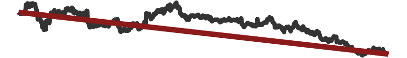

Meta

$206.75

$116.40

-$90.35

-43.70%

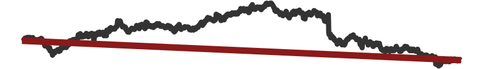

Salesforce

$163.92

$129.70

-$34.22

-20.88%

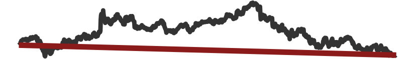

Netflix

$326.10

$283.18

-$42.92

-13.16%

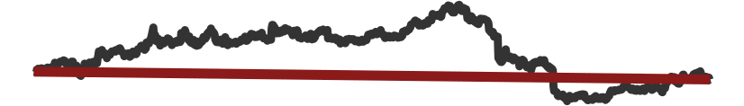

Amazon

$93.75

$82.87

-$10.88

-11.61%

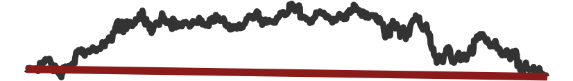

Cisco

$48.06

$47.26

-$0.80

-1.66%

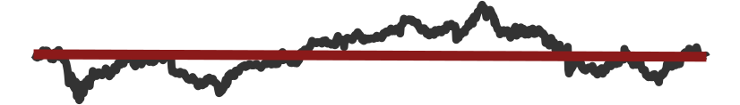

Adobe

$330.00

$330.75

$0.75

0.23%

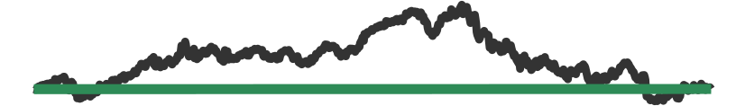

IBM

$129.06

$140.58

$11.52

8.92%

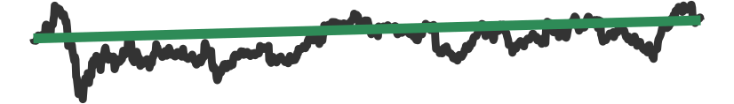

Alphabet

$67.42

$86.62

$19.20

28.48%

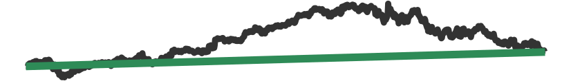

Microsoft

$158.78

$235.65

$76.87

48.41%

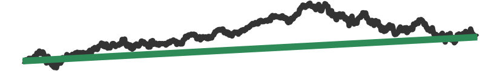

Oracle

$53.27

$80.97

$27.70

52.00%

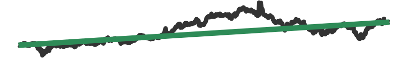

Apple

$74.06

$127.99

$53.93

72.82%

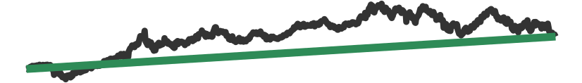

NVIDIA

$59.69

$144.02

$84.33

141.29%

[2 more figures not shown]

```r
default_font <- 'Source Sans Pro'
default_font_color <- 'grey20'
default_font_size <- 12
set_flextable_defaults(
  font.family = default_font,
  font.color = default_font_color,
  font.size = default_font_size,
  border.color = 'grey40',
)

tbl_data |>
  flextable() |>
  set_header_labels(
    stock_symbol = 'Opening prices over time',
    company = '',
    logo = '',
    open2020 = 'Jan 02, 2020',
    open2022 = 'Dec 29, 2022',
    change_abs = 'abs.',
    percent = 'rel.'
  ) |>
  add_header_row(
    values = c('', 'Opening Prices', 'Change', ''),
    colwidths = c(1, 2, 2, 1)
  ) |>
  add_header_lines(
    values = c('Not all tech companies are COVID winners',
    'During the pandemic, tech companies were hyped as COVID winners. Their stock prices surged while most other companies struggled. But not every tech company was so lucky in the end.')
  ) |>
  align(j = 'percent', align = 'right', part = 'header') |>
  align(j = 'percent', align = 'right', part = 'body') |>
  align(i = 3, part = 'header', align = 'center') |>
  flextable::compose(
    j = 'stock_symbol',
    value = as_paragraph(
      gg_chunk(
        value = list_of_ggplots,
        width = 7,
        height = 1,
        unit = 'cm'
      )
    )
  ) |>
  autofit() |>
  width(j = 'stock_symbol', width = 6, unit = 'cm') |>
  set_formatter(
    open2020 = function(x) scales::dollar(x),
    open2022 = function(x) scales::dollar(x),
    change_abs = function(x) scales::dollar(x)
  ) |>
  border(
    i = 1:3,
    part = 'header',
    border.bottom = fp_border_default(width = 1),
    border.top = fp_border_default(width = 1)
  ) |>
  border(
    i = 14,
    border.bottom = fp_border_default(width = 1.5)
  ) |>
  border(i = 1, border.bottom = fp_border_default(width = 0), part = 'header') |>
  border(i = 2, border.top = fp_border_default(width = 0), part = 'header') |>
  border(i = 3, j = c(1, 6), border.bottom = fp_border_default(width = 0), part = 'header') |>
  border(i = 4, j = c(1, 6), border.top = fp_border_default(width = 0), part = 'header') |>
  style(
    i = 3, j = 2:5,
    pr_t = fp_text_default(
      bold = TRUE
    ),
    part = 'header'
  ) |>
  style(
    i = 4, j = 6, part = 'header',
    pr_t = fp_text_default(bold = TRUE)
  ) |>
  style(
    i = ~ change_abs < 0,
    j = c('change_abs', 'percent'),
    pr_t = fp_text_default(
      bold = TRUE,
      color = chart_segment_color_neg
    )
  ) |>
  style(
    i = ~ change_abs >= 0,
    j = c('change_abs', 'percent'),
    pr_t = fp_text_default(
      bold = TRUE,
      color = chart_segment_color_pos
    )
  ) |>
  style(
    i = 1, part = 'header',
    pr_t = fp_text_default(
      font.size = 24,
      font.family = 'Merriweather',
      bold = TRUE
    )
  ) |>
  style(
    i = 2, part = 'header',
    pr_t = fp_text_default(
      font.size = 16,
      font.family = 'Source Sans Pro'
    )
  ) |>
  border(
    i = 1:13,
    border.bottom = fp_border_default(color = 'grey80', width = 0.5)
  )
```

### Code and Video solutions

### Learn more